# Practical Machine Learning R markdown

Ridwan Kurniawan

Sunday, September 21, 2014

This is an R Markdown document for Coursera Practical Machine Learning submission. R code involved at each step will be numbered accordingly and display as a code chunk

1. Initialization of seed and working directory to publish prediction result and definition of function

```r
set.seed(32323)
setwd("F:/Study/Coursera/Practical Machine Learning/Project/")

pml_write_files = function(x){
  n = length(x)
    for(i in 1:n){
        filename = paste0("problem_id_",i,".txt")
        write.table(x[i],file=filename,quote=FALSE,row.names=FALSE,col.names=FALSE)
    }
}
```

2. Import required library to project

```r
library(caret); library(kernlab); library(ggplot2)
library(foreach); library(randomForest); library(doParallel)
```

3. Import training and testing data

```r
ori_trainfile <- read.csv("F:/Study/Coursera/Practical Machine Learning/Project/pml-training.csv")
ori_testfile <- read.csv("F:/Study/Coursera/Practical Machine Learning/Project/pml-testing.csv")
```

4. Finalize data column to be used (remove near zero variance, NA, and empty column for both ori_train/test file)

```r
ori_trainfile <- ori_trainfile[, 3:dim(ori_trainfile)[2]]
ori_testfile <- ori_testfile[, 3:dim(ori_testfile)[2]]
miss_row <- dim(ori_trainfile)[1] * 0.90
excludecolumn <- apply(ori_trainfile, 2, function(row) sum(is.na(row)) > miss_row || sum(row == "") > miss_row)
ori_trainfile <- ori_trainfile[,!excludecolumn]
ori_testfile <- ori_testfile[,!excludecolumn]

zero_var_col <- nearZeroVar(ori_trainfile,saveMetrics = TRUE)
ori_trainfile <- ori_trainfile[,zero_var_col$nzv == FALSE]
ori_testfile <- ori_testfile[,zero_var_col$nzv == FALSE]

ori_trainfile <- ori_trainfile[,-3]; ori_testfile <- ori_testfile[,-3]
```

5. Testing correlation matrix and illustrate non linearness by feature plot

```r
corrmatrix <- abs(cor(ori_trainfile[,-ncol(ori_trainfile)])); diag(corrmatrix)<-0
sum(corrmatrix > 0.8)
```

```
## [1] 38
```

```r
which(corrmatrix > 0.8,arr.ind=T)
```

```
##                  row col
## yaw_belt           6   4
## total_accel_belt   7   4
## accel_belt_y      12   4
## accel_belt_z      13   4
## accel_belt_x      11   5
## magnet_belt_x     14   5
## roll_belt          4   6
## roll_belt          4   7
## accel_belt_y      12   7
## accel_belt_z      13   7
## pitch_belt         5  11
## magnet_belt_x     14  11
## roll_belt          4  12
## total_accel_belt   7  12
## accel_belt_z      13  12
## roll_belt          4  13
## total_accel_belt   7  13
## accel_belt_y      12  13
## pitch_belt         5  14
## accel_belt_x      11  14
## gyros_arm_y       22  21
## gyros_arm_x       21  22
## magnet_arm_x      27  24
## accel_arm_x       24  27
## magnet_arm_z      29  28
## magnet_arm_y      28  29
## accel_dumbbell_x  37  31
## accel_dumbbell_z  39  32
## gyros_dumbbell_z  36  34
## gyros_forearm_z   49  34
## gyros_dumbbell_x  34  36
## gyros_forearm_z   49  36
## pitch_dumbbell    31  37
## yaw_dumbbell      32  39
## gyros_forearm_z   49  48
## gyros_dumbbell_x  34  49
## gyros_dumbbell_z  36  49
## gyros_forearm_y   48  49
```

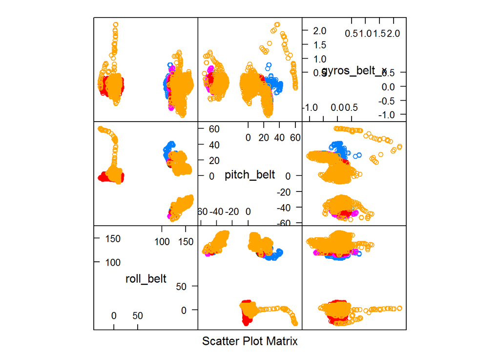

```r
featurePlot(x=ori_trainfile[,c("roll_belt","pitch_belt","gyros_belt_x")],y=ori_trainfile$classe,plot="pairs")
```

As can be seen. Only 38 pairs (19 combinations) out of 1485 combinations are highly correlated (i.e. correlation > 0.8). Feature plots illustrate the this non-linear relationship in general.

6. Data slicing (training, cross validation), train model, and cross validation result using random forests algorithm. Using parallel processing to fit the random forest algorithm

```r
inTrain <- createDataPartition(y=ori_trainfile$classe,p=0.6,list=FALSE)
training <- ori_trainfile[inTrain,]
crossvalid <- ori_trainfile[-inTrain,]

x <- training[,-ncol(training)]
y <- training$classe
parrf_modfit <- foreach(ntree=rep(250, 4), .combine=combine, .packages='randomForest') %dopar%
    {randomForest(x, y, ntree=ntree)}
parrf_modfit
```

```
##
## Call:
##  randomForest(x = x, y = y, ntree = ntree)
##                Type of random forest: classification
##                      Number of trees: 1000
## No. of variables tried at each split: 7
```

```r
predtrain <- predict(parrf_modfit,training[,-ncol(training)])
table(predtrain,training$classe)
```

```
##
## predtrain    A    B    C    D    E
##         A 3348    0    0    0    0
##         B    0 2279    0    0    0
##         C    0    0 2054    0    0
##         D    0    0    0 1930    0
##         E    0    0    0    0 2165
```

```r
confusionMatrix(predtrain,training$classe)
```

```
## Confusion Matrix and Statistics
##
##           Reference
## Prediction    A    B    C    D    E
##          A 3348    0    0    0    0
##          B    0 2279    0    0    0
##          C    0    0 2054    0    0
##          D    0    0    0 1930    0
##          E    0    0    0    0 2165
##
## Overall Statistics
##
##                Accuracy : 1
##                  95% CI : (1, 1)
##     No Information Rate : 0.284
##     P-Value [Acc > NIR] : <2e-16
##
##                   Kappa : 1
##  Mcnemar's Test P-Value : NA
##
## Statistics by Class:
##
##                      Class: A Class: B Class: C Class: D Class: E
## Sensitivity             1.000    1.000    1.000    1.000    1.000
## Specificity             1.000    1.000    1.000    1.000    1.000
## Pos Pred Value          1.000    1.000    1.000    1.000    1.000
## Neg Pred Value          1.000    1.000    1.000    1.000    1.000
## Prevalence              0.284    0.194    0.174    0.164    0.184
## Detection Rate          0.284    0.194    0.174    0.164    0.184
## Detection Prevalence    0.284    0.194    0.174    0.164    0.184
## Balanced Accuracy       1.000    1.000    1.000    1.000    1.000
```

```r
predcross <- predict(parrf_modfit,crossvalid[,-ncol(crossvalid)])
table(predcross,crossvalid$classe)
```

```
##
## predcross    A    B    C    D    E
##         A 2232    4    0    0    0
##         B    0 1514    6    0    0
##         C    0    0 1362    1    0
##         D    0    0    0 1285    2
##         E    0    0    0    0 1440
```

```r
confusionMatrix(predcross,crossvalid$classe)
```

```
## Confusion Matrix and Statistics
##
##           Reference
## Prediction    A    B    C    D    E
##          A 2232    4    0    0    0
##          B    0 1514    6    0    0
##          C    0    0 1362    1    0
##          D    0    0    0 1285    2
##          E    0    0    0    0 1440
##
## Overall Statistics
##
##                Accuracy : 0.998
##                  95% CI : (0.997, 0.999)
##     No Information Rate : 0.284
##     P-Value [Acc > NIR] : <2e-16
##
##                   Kappa : 0.998
##  Mcnemar's Test P-Value : NA
##
## Statistics by Class:
##
##                      Class: A Class: B Class: C Class: D Class: E
## Sensitivity             1.000    0.997    0.996    0.999    0.999
## Specificity             0.999    0.999    1.000    1.000    1.000
## Pos Pred Value          0.998    0.996    0.999    0.998    1.000
## Neg Pred Value          1.000    0.999    0.999    1.000    1.000
## Prevalence              0.284    0.193    0.174    0.164    0.184
## Detection Rate          0.284    0.193    0.174    0.164    0.184
## Detection Prevalence    0.285    0.194    0.174    0.164    0.184
## Balanced Accuracy       1.000    0.998    0.998    0.999    0.999
```

7. Predict the final outcome using real testing file (ori_testfile)

```r
predfinal <- predict(parrf_modfit,ori_testfile[,-ncol(ori_testfile)])
predfinal
```

```
##  1  2  3  4  5  6  7  8  9 10 11 12 13 14 15 16 17 18 19 20
##  B  A  B  A  A  E  D  B  A  A  B  C  B  A  E  E  A  B  B  B
## Levels: A B C D E
```

```r
pml_write_files(predfinal)
alarm()
```

Thanks for reviewing. Appreciate your time and hope you enjoy the course as much as i do :)